# Notebook 20160801_20160807

- 1. make disaggregate algorithm faster
  - 1.1 previous bayesian algorithm wrote in the last week
  - 1.2 make code more robust
  - 1.3 make the code faster
- 2. Cluster and mode of power changes around change point
  - 2.1 Align power usage after change points, and normalization
  - 2.2 disaggregate data from a few days, and align
  - 2.3 Align all data from April 2016
  - 2.4 load more data, from 2016/3/22 ~ 2016/7/31
  - 2.5 Align all data from four months in 2016
  - 2.6 cluster
- 3. revisit disaggregation algorithm using known patterns
  - 3.1 basic algorithm that utilize the shapes of each cluster

```python
# load a few necessary packages

%matplotlib inline

import numpy as np
import scipy as sp
import matplotlib as mpl
import matplotlib.cm as cm
import matplotlib.pyplot as plt
import pandas as pd
import time
pd.set_option('display.width', 500)
pd.set_option('display.max_columns', 100)
pd.set_option('display.notebook_repr_html', True)
try:
    import seaborn as sns
    sns.set_style("whitegrid")
    sns.set_context("poster")
```

# 1. make disaggregate algorithm faster

## 1.1 previous bayesian algorithm wrote in the last week

```python
# prepare example data
from bayesian_cp_detect import file_readef

def load_dat(date, Hstart, Hend, folder='data/IHG/'):
    (t,y)=np.array(file_readef.readfile(date,Hstart,Hend,folder))
    return t, y
```

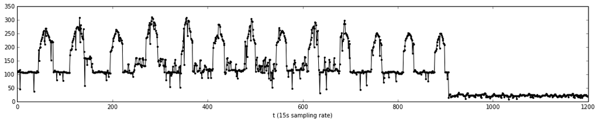

```python
# example data, should be easy to disaggregate
# plot the example data

t_raw_4_16_19_23, y_raw_4_16_19_23 = load_dat('4-16', 19, 23, 'data/IHG/')

plt.figure(figsize=[18,3])
plt.plot(t_raw_4_16_19_23, y_raw_4_16_19_23, 'k.-')
plt.xlabel('t (15s sampling rate)')
```

```python
from bayesian_cp_detect import cp_detect
from bayesian_cp_detect import outlierdef
```

```python
%%time

y_raw = y_raw_4_16_19_23
y = outlierdef.preprocess(y_raw)

print 'size of input: %d' % len(y)
[mu_list_list, sigma_list_list, prob_r_list_list] = cp_detect.bayesian_change_point(y)
changepoint, changepoint_p = cp_detect.get_change_point(prob_r_list_list)
```

```
size of input: 1200
CPU times: user 974 ms, sys: 23.3 ms, total: 997 ms
Wall time: 985 ms
```

```python
# write a function overlay change points to raw data
def plot_with_cp(y, cp_list=[]):
    plt.figure(figsize=(18,3))
    plt.plot(y, 'k-', linewidth=2)
    for cp in cp_list:
        plt.plot([cp,cp], [0, 500], 'k--', linewidth=1)
    plt.xlabel('t')
    plt.ylabel('power')
```

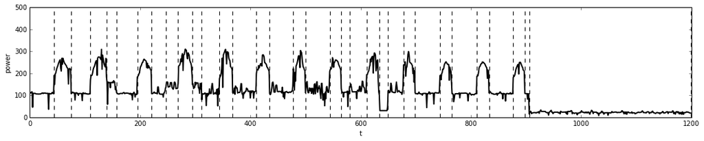

```python
plot_with_cp(y, changepoint)
```

## 1.2 make code more robust

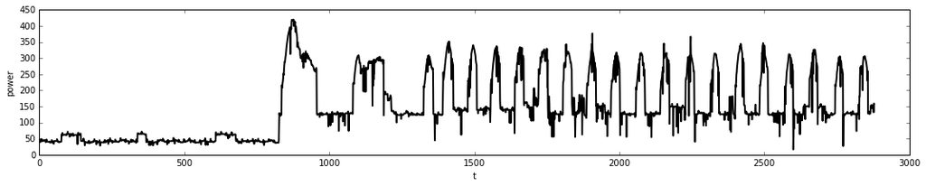

```python
# load a example of "difficult" data
t_raw_4_3_7_18, y_raw_4_3_7_18 = load_dat('4-3', 7, 18, 'data/IHG/')
plot_with_cp(y_raw_4_3_7_18)
```

```python
%%time

# segment using previous version

y_raw = y_raw_4_3_7_18
y = outlierdef.preprocess(y_raw)

print 'size of input: %d' % len(y)
[mu_list_list, sigma_list_list, prob_r_list_list] = cp_detect.bayesian_change_point(y)
changepoint, changepoint_p = cp_detect.get_change_point(prob_r_list_list)
```

```
size of input: 2880
CPU times: user 5.27 s, sys: 34 ms, total: 5.31 s
Wall time: 5.35 s
```

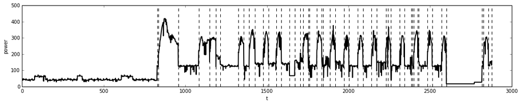

```python
plot_with_cp(y, changepoint)
```

#### Note that there are 2 problems

- it is slower than before, takes ~ 5 seconds
- disaggregate ~2200 is bad - a change point was detected due to bad data

```
(2200, 2300)
```

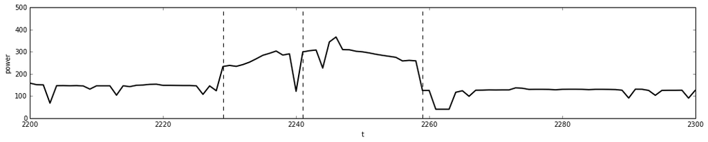

```python
plot_with_cp(y, changepoint)
plt.xlim([2200, 2300])
```

To solve the bad point problem, a filter based on relative change is introduced. The idea is that the relative to the closest point (either left or right, whichever closer) should not be too large. To not include points during rapid change, this method only filter points that are either higher or lower than both near points

```python
def rel_change(y):
    return np.min([np.abs(y[1] - y[0]), np.abs(y[1] - y[2])]) / float(y[1])

def rel_change_filter(t, data_input, thre=.2):
    id_filter = [i for i in range(1, len(data_input)-1)
     if (data_input[i]>data_input[i-1] and data_input[i]>data_input[i+1] and rel_change(data_input[i-1:i+2])>thre) or
                 (data_input[i]<data_input[i-1] and data_input[i]<data_input[i+1] and rel_change(data_input[i-1:i+2])>thre/(1-thre))
    ]
    id_filter2 = np.setdiff1d(range(len(data_input)), id_filter)
    t_2 = [t[i] for i in id_filter2]
    data_input_2 = [data_input[i] for i in id_filter2]
    return t_2, data_input_2
```

```python
%%time

# segment using previous version
t_raw = t_raw_4_3_7_18
y_raw = y_raw_4_3_7_18
t_2, y_2 = rel_change_filter(t_raw, y_raw,thre=.2)

print 'size of input: %d' % len(y)
[mu_list_list, sigma_list_list, prob_r_list_list] = cp_detect.bayesian_change_point(y_2)
changepoint, changepoint_p = cp_detect.get_change_point(prob_r_list_list)
```

```
size of input: 2880
CPU times: user 4.99 s, sys: 66.1 ms, total: 5.05 s
Wall time: 5.03 s
```

```
(2200, 2300)
```

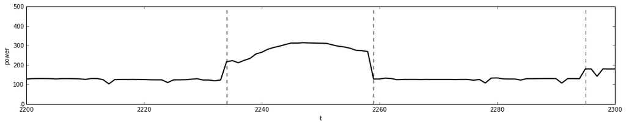

```python
plot_with_cp(y_2, changepoint)
plt.xlim([2200, 2300])
```

## 1.3 make the code faster

## 1.3.1 the problem

We will look at the "good data" again, to see can we make it even faster, and then apply to a more difficult situation

```python
%%time

t_raw = t_raw_4_16_19_23
y_raw = y_raw_4_16_19_23
t_2, y_2 = rel_change_filter(t_raw, y_raw,thre=.2)

print 'size of input: %d' % len(y)
[mu_list_list, sigma_list_list, prob_r_list_list] = cp_detect.bayesian_change_point(y_2)
changepoint, changepoint_p = cp_detect.get_change_point(prob_r_list_list)
```

```
size of input: 1200
CPU times: user 889 ms, sys: 13.7 ms, total: 903 ms
Wall time: 901 ms
```

```python
plot_with_cp(y_2, changepoint)
```

#### the problem is during the region that there is not too much changes

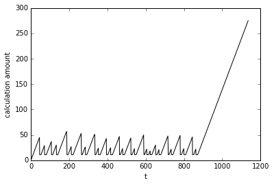

```python
plt.plot([len(x) for x in prob_r_list_list],'k-')
plt.xlabel('t')
plt.ylabel('calculation amount')
```

## 1.3.2 filtering probability

**the code below uses a new version of bayesian_change_point**

bayesian_change_point_3 did one step of filtering of list of r (r is the distance to the last change point). If the prob of certain r is lower than a threshold, it is filtered

**note that the speed using bayesian_change_point_3 is faster then bayesian_change_point**

```python
%%time

t_raw = t_raw_4_16_19_23
y_raw = y_raw_4_16_19_23
t_2, y_2 = rel_change_filter(t_raw, y_raw,thre=.2)

print 'size of input: %d' % len(y)
[mu_list_list, sigma_list_list, prob_r_list_list, r_list_list] = cp_detect.bayesian_change_point_3(y_2)
changepoint, changepoint_p = cp_detect.get_change_point(prob_r_list_list)
```

```
size of input: 1200
CPU times: user 562 ms, sys: 11.8 ms, total: 574 ms
Wall time: 581 ms
```

```python
plot_with_cp(y_2, changepoint)
```

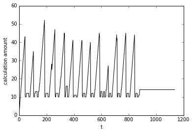

```python
plt.plot([len(x) for x in prob_r_list_list],'k-')
plt.xlabel('t')
plt.ylabel('calculation amount')
```

```python
%%time
# try a more "difficult" data

t_raw = t_raw_4_3_7_18
y_raw = y_raw_4_3_7_18
t_2, y_2 = rel_change_filter(t_raw, y_raw,thre=.2)

print 'size of input: %d' % len(y)
[mu_list_list, sigma_list_list, prob_r_list_list, r_list_list] = cp_detect.bayesian_change_point_3(y_2)
changepoint, changepoint_p = cp_detect.get_change_point(prob_r_list_list)
```

```
size of input: 1200
CPU times: user 1.39 s, sys: 14.2 ms, total: 1.41 s
Wall time: 1.55 s
```

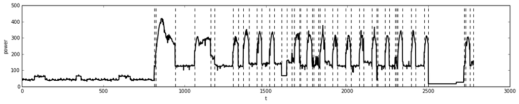

```python
plot_with_cp(y_2, changepoint)
```

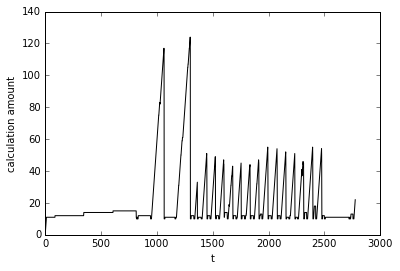

```python
plt.plot([len(x) for x in prob_r_list_list],'k-')
plt.xlabel('t')
plt.ylabel('calculation amount')
```

## 1.3.3 More filtering

in bayesian_change_point_4, we will also filter r if r is larger than a certain threshold and is not close to the largest r. This is the situation where power does not really change much.

In the example below, the performance decreases, but not much. This is due to the extra calculation done. But I expect the performance is much better for even worse data

```python
%%time
# try a more "difficult" data

t_raw = t_raw_4_3_7_18
y_raw = y_raw_4_3_7_18
t_2, y_2 = rel_change_filter(t_raw, y_raw,thre=.2)

print 'size of input: %d' % len(y)
[mu_list_list, sigma_list_list, prob_r_list_list, r_list_list] = cp_detect.bayesian_change_point_4(y_2)
changepoint, changepoint_p = cp_detect.get_change_point(prob_r_list_list)
```

```
size of input: 1200
CPU times: user 1.53 s, sys: 40.4 ms, total: 1.57 s
Wall time: 1.74 s
```

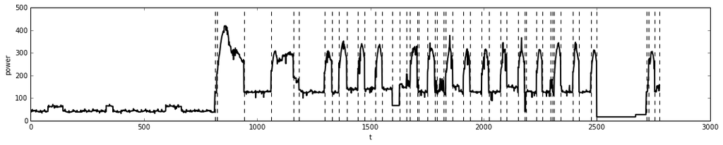

```python
plot_with_cp(y_2, changepoint)
```

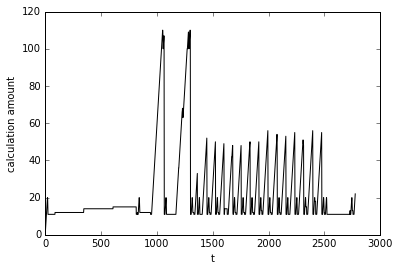

```python
plt.plot([len(x) for x in prob_r_list_list],'k-')
plt.xlabel('t')
plt.ylabel('calculation amount')
```

```python
# load even worst data
t_raw_4_4_7_18, y_raw_4_4_7_18 = load_dat('4-4', 7, 18, 'data/IHG/')
```

```python
%%time

t_raw = t_raw_4_4_7_18
y_raw = y_raw_4_4_7_18
t_2, y_2 = rel_change_filter(t_raw, y_raw,thre=.2)

print 'size of input: %d' % len(y)
[mu_list_list, sigma_list_list, prob_r_list_list, r_list_list] = cp_detect.bayesian_change_point_3(y_2)
changepoint, changepoint_p = cp_detect.get_change_point(prob_r_list_list)
```

```
size of input: 1200
CPU times: user 13 s, sys: 184 ms, total: 13.2 s
Wall time: 13.3 s
```

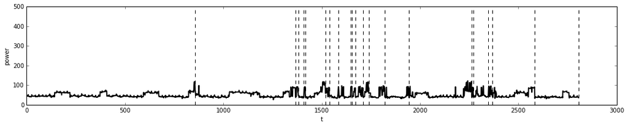

```python
plot_with_cp(y_2, changepoint)
```

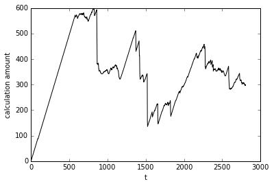

```python
plt.plot([len(x) for x in prob_r_list_list],'k-')
plt.xlabel('t')
plt.ylabel('calculation amount')
```

```python
%%time

t_raw = t_raw_4_4_7_18
y_raw = y_raw_4_4_7_18
t_2, y_2 = rel_change_filter(t_raw, y_raw,thre=.2)

print 'size of input: %d' % len(y)
[mu_list_list, sigma_list_list, prob_r_list_list, r_list_list] = cp_detect.bayesian_change_point_4(y_2)
changepoint, changepoint_p = cp_detect.get_change_point(prob_r_list_list)
```

```
size of input: 1200
CPU times: user 4.61 s, sys: 67.2 ms, total: 4.68 s
Wall time: 4.81 s
```

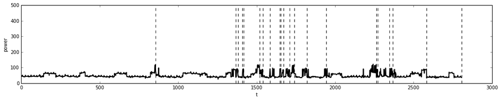

```python
plot_with_cp(y_2, changepoint)
```

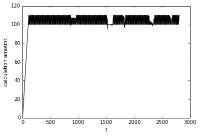

```python
plt.plot([len(x) for x in prob_r_list_list],'k-')
plt.xlabel('t')
plt.ylabel('calculation amount')
```

## 1.3.4 summary

Nothing new. Just going to run on good data again just to summarize where we are in terms of speed and performance

```python
%%time

t_raw = t_raw_4_16_19_23
y_raw = y_raw_4_16_19_23
t_2, y_2 = rel_change_filter(t_raw, y_raw,thre=.2)

print 'size of input: %d' % len(y)
[mu_list_list, sigma_list_list, prob_r_list_list, r_list_list] = cp_detect.bayesian_change_point_4(y_2)
changepoint, changepoint_p = cp_detect.get_change_point(prob_r_list_list)
```

```
size of input: 1200
CPU times: user 542 ms, sys: 33.2 ms, total: 576 ms
Wall time: 559 ms
```

```python
plot_with_cp(y_2, changepoint)
```

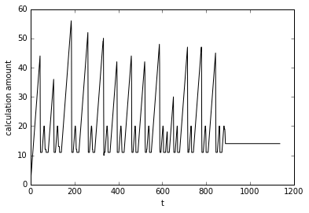

```python
plt.plot([len(x) for x in prob_r_list_list],'k-')
plt.xlabel('t')
plt.ylabel('calculation amount')
```

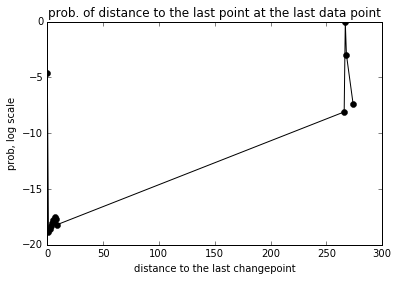

```python
plt.plot(r_list_list[-1], prob_r_list_list[-1], 'ko-')
plt.xlabel('distance to the last changepoint')
plt.ylabel('prob, log scale')
plt.title('prob. of distance to the last point at the last data point')
```

# 2. Cluster and mode of power changes around change point

## 2.1 Align power usage after change points, and normalization

two helper functions: filter_dat will filter data, disaggregate will align all change points

```python
def filter_dat(t, y):
    t_2, y_2 = rel_change_filter(t, y, thre=.2)
    return t_2, y_2

def disaggregate(dat):
    mu_list_list, sigma_list_list, prob_r_list_list, r_list_list = cp_detect.bayesian_change_point_4(dat, r_blur=30)
    changepoint, changepoint_p = cp_detect.get_change_point(prob_r_list_list)
    dat_seg = [dat[cp_1:cp_2] for cp_1, cp_2 in zip(changepoint[:-1], changepoint[1:])]
    return dat_seg, changepoint
```

```python
%%time

t_raw = t_raw_4_16_19_23
y_raw = y_raw_4_16_19_23
t_2, y_2 = filter_dat(t_raw, y_raw)
dat_seg, changepoint = disaggregate(y_2)
# print 'size of input: %d' % len(y)
# [mu_list_list, sigma_list_list, prob_r_list_list, r_list_list] = cp_detect.bayesian_change_point_4(y_2)
# changepoint, changepoint_p = cp_detect.get_change_point(prob_r_list_list)
```

```
CPU times: user 517 ms, sys: 3.84 ms, total: 521 ms
Wall time: 520 ms
```

```
the number of seg: 31
```

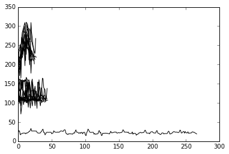

```python
print 'the number of seg:', len(dat_seg)
for seg in dat_seg:
    plt.plot(seg, 'k-')
```

**let us avoid the long non-changing segment by focusing on the first 100 points**

```
the number of seg: 31
```

```
(0, 100)
```

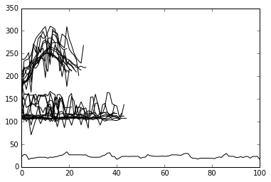

```python
print 'the number of seg:', len(dat_seg)
for seg in dat_seg:
    plt.plot(seg, 'k-')
plt.xlim([0,100])
```

The function below will take the aligned segments, and use the last data point from the last segment to calculate the change in power usage

```python
def normalize_by_last_point(dat_seg):
    last_p = 0
    new_dat_seg = []
    for seg in dat_seg:
        new_dat_seg.append([x - last_p for x in seg])
        last_p = seg[-1]
    new_dat_seg.pop(0)
    return new_dat_seg
```

```
the number of seg: 30
```

```
(0, 100)
```

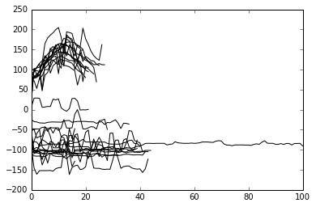

```python
dat_seg_new = normalize_by_last_point(dat_seg)
print 'the number of seg:', len(dat_seg_new)
for seg in dat_seg_new:
    plt.plot(seg, 'k-')
plt.xlim([0,100])
```

**maybe the last point includes too much noise, the function below normalize by the last n points**

Although it does not look very different, the code below will use this function by default

```python
def normalize_by_last_n_point(dat_seg, n=3):
    last_p = 0
    new_dat_seg = []
    for seg in dat_seg:
        new_dat_seg.append([x - last_p for x in seg])
        last_p = np.mean(seg[-n:])
    new_dat_seg.pop(0)
    return new_dat_seg
```

```
the number of seg: 30
```

```
(0, 100)
```

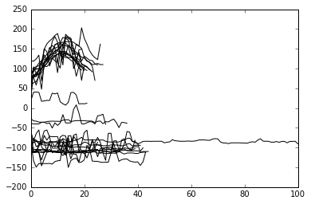

```python
dat_seg_new = normalize_by_last_n_point(dat_seg)
print 'the number of seg:', len(dat_seg_new)
for seg in dat_seg_new:
    plt.plot(seg, 'k-')
plt.xlim([0,100])
```

## 2.2 disaggregate data from a few days, and align

wrote a function that takes date, start and end time. plot the aligned the results

**importantly, note the similarity between different days**

```python
def align_cp_plot_2(date, Hstart, Hend):
    t, y = load_dat(date, Hstart, Hend)
    t, y = filter_dat(t, y)
    [dat_seg, changepoint] = disaggregate(y)
    dat_seg_new = normalize_by_last_n_point(dat_seg)
    for seg in dat_seg_new:
        plt.plot(seg, 'k-')
    plt.xlim([0, 100])
    plt.xlabel('time after change point')
    plt.ylabel('power change since the last change point')
    plt.title(date+' ('+str(Hstart)+'-'+str(Hend)+'h)')
#     plt.title(date, Hstart, Hend)
```

```
CPU times: user 606 ms, sys: 2.24 ms, total: 609 ms
Wall time: 609 ms
```

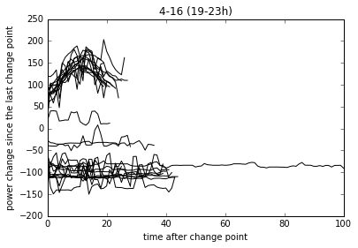

```python
%%time
align_cp_plot_2('4-16', 19, 23) # good data again
```

```
CPU times: user 1.93 s, sys: 16.4 ms, total: 1.95 s
Wall time: 2.05 s
```

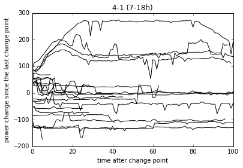

```python
%%time
align_cp_plot_2('4-1', 7, 18)
```

```
CPU times: user 1.47 s, sys: 10.9 ms, total: 1.48 s
Wall time: 1.52 s
```

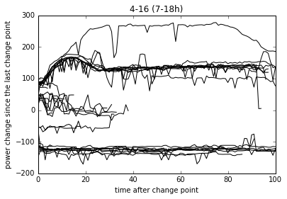

```python
%%time
align_cp_plot_2('4-16', 7, 18)
```

```
CPU times: user 1.55 s, sys: 18.7 ms, total: 1.57 s
Wall time: 1.59 s
```

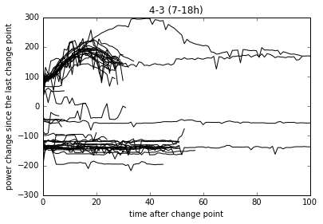

```python
%%time
align_cp_plot_2('4-3', 7, 18)
```

## 2.3 Align all data from April 2016

There are two variables used to record disaggregated signals, all_seg is list, each element is all segments within the same day; all_seg_2 is the flatten version of all_seg

```python
def dissaggregate_align_pool(date_start, date_end, Hstart, Hend):

    date_current = date_start

    all_seg = []
    all_seg_2 = []

    while date_current < date_end:
        date = str(date_current.month) + '-' + str(date_current.day)
        print 'reading', date, Hstart, Hend

        t, y = load_dat(date, Hstart, Hend)
        t, y = filter_dat(t, y)
        [dat_seg, changepoint] = disaggregate(y)
        dat_seg_new = normalize_by_last_n_point(dat_seg)

        all_seg.append(dat_seg_new)
        all_seg_2.extend(dat_seg_new)

        date_current += datetime.timedelta(1)
    return all_seg, all_seg_2
```

```python
import datetime
```

```python
date_start = datetime.date(2016,4,1)
date_end = datetime.date(2016,5,1)

Hstart=7
Hend=18

all_seg_april_last, all_seg_2_april_last = dissaggregate_align_pool(date_start
                                                                   , date_end
                                                                   , Hstart
                                                                   , Hend)
```

```
reading 4-1 7 18
reading 4-2 7 18
reading 4-3 7 18
reading 4-4 7 18
reading 4-5 7 18
reading 4-6 7 18
reading 4-7 7 18
reading 4-8 7 18
reading 4-9 7 18
reading 4-10 7 18
reading 4-11 7 18
reading 4-12 7 18
reading 4-13 7 18
reading 4-14 7 18
reading 4-15 7 18
reading 4-16 7 18
reading 4-17 7 18
reading 4-18 7 18
reading 4-19 7 18
reading 4-20 7 18
reading 4-21 7 18
reading 4-22 7 18
reading 4-23 7 18
reading 4-24 7 18
reading 4-25 7 18
reading 4-26 7 18
reading 4-27 7 18
reading 4-28 7 18
reading 4-29 7 18
reading 4-30 7 18
```

**Plot all segments in April**

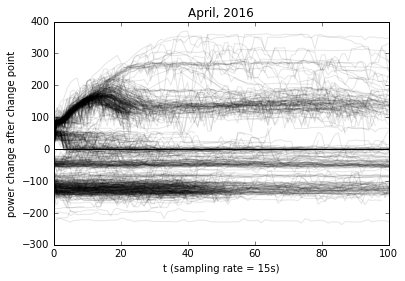

```python
for seg in all_seg_2_april_last:
    plt.plot(seg, 'k-', linewidth=1, alpha=.1)
plt.plot([0,100], [0,0], 'k-', linewidth=1)
plt.xlim([0,100])
plt.xlabel('t (sampling rate = 15s)')
plt.ylabel('power change after change point')
plt.title('April, 2016')
```

## 2.4 load more data, from 2016/3/22 ~ 2016/7/31

```python
# run downloader.py
# python downloader.py > downloader.py.log
```

**make sure that data looks just as before**

*Note that somehow data is shifted......*

```python
from os import path
def read_dat(date, h_start, h_end, folder_path):
    dat = []
    for h in range(h_start, h_end):
        try:
            file_name = '%d-%d-%d.csv' % (date.month, date.day, h)
            file_path = path.join(folder_path, file_name)
            tmp = pd.read_csv( file_path )
            dat.extend( [t[1]/3 for t in tmp.values] )
        except:
            print '%s failed' % file_path
    return dat
```

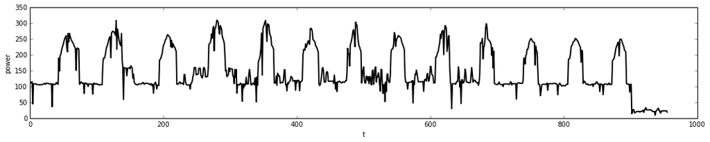

```python
dat = read_dat(datetime.datetime(2016, 4, 16), 19, 23, folder_path='new_data/IHG')
y = range(len(dat))

plot_with_cp(dat)
```

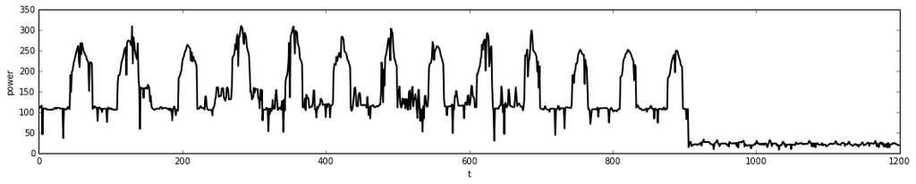

```python
plot_with_cp(y_raw_4_16_19_23)
```

## 2.5 Align all data from four months in 2016

```python
def dissaggregate_align_pool(date_start, date_end, Hstart, Hend):

    date_current = date_start

    all_seg = []
    all_seg_2 = []
    all_seg_time = []

    while date_current < date_end:
        date = str(date_current.month) + '-' + str(date_current.day)
        print 'reading', date, Hstart, Hend
        dat = read_dat(date_current, Hstart, Hend, folder_path='new_data/IHG')
        t = range(len(dat)) # fake time
        try:
            t, y = filter_dat(t, dat)
            [dat_seg, changepoint] = disaggregate(y)
            dat_seg_new = normalize_by_last_n_point(dat_seg)
        except:
            dat_seg_new = []

#         [dat_seg, changepoint] = disaggregate(y)
#         dat_seg_new = normalize_by_last_point(dat_seg)

        all_seg.append(dat_seg_new)
        all_seg_2.extend(dat_seg_new)
        all_seg_time.append((date_current, Hstart, Hend))

        date_current += datetime.timedelta(1)
    return all_seg, all_seg_2, all_seg_time
```

```python
date_start = datetime.date(2016,4,1)
date_end = datetime.date(2016,8,1)

Hstart=7
Hend=18

all_seg_4_month, all_seg_2_4_month, all_seg_time_4_month = dissaggregate_align_pool(date_start
                                                                                    , date_end
                                                                                    , Hstart
                                                                                    , Hend)
```

```
reading 4-1 7 18
reading 4-2 7 18
reading 4-3 7 18
reading 4-4 7 18
reading 4-5 7 18
reading 4-6 7 18
reading 4-7 7 18
reading 4-8 7 18
reading 4-9 7 18
reading 4-10 7 18
reading 4-11 7 18
reading 4-12 7 18
reading 4-13 7 18
reading 4-14 7 18
reading 4-15 7 18
reading 4-16 7 18
reading 4-17 7 18
reading 4-18 7 18
reading 4-19 7 18
reading 4-20 7 18
reading 4-21 7 18
reading 4-22 7 18
reading 4-23 7 18
reading 4-24 7 18
reading 4-25 7 18
reading 4-26 7 18
reading 4-27 7 18
reading 4-28 7 18
reading 4-29 7 18
reading 4-30 7 18
reading 5-1 7 18
reading 5-2 7 18
reading 5-3 7 18
reading 5-4 7 18
reading 5-5 7 18
reading 5-6 7 18
new_data/IHG/5-6-8.csv failed
reading 5-7 7 18
reading 5-8 7 18
new_data/IHG/5-8-9.csv failed
```

[output cut: 10 more lines]

```
reading 5-19 7 18
reading 5-20 7 18
reading 5-21 7 18
new_data/IHG/5-21-7.csv failed
new_data/IHG/5-21-8.csv failed
new_data/IHG/5-21-9.csv failed
new_data/IHG/5-21-10.csv failed
new_data/IHG/5-21-11.csv failed
new_data/IHG/5-21-12.csv failed
new_data/IHG/5-21-13.csv failed
new_data/IHG/5-21-14.csv failed
new_data/IHG/5-21-15.csv failed
new_data/IHG/5-21-16.csv failed
new_data/IHG/5-21-17.csv failed
reading 5-22 7 18
```

```
reading 5-23 7 18
reading 5-24 7 18
reading 5-25 7 18
reading 5-26 7 18
reading 5-27 7 18
reading 5-28 7 18
reading 5-29 7 18
reading 5-30 7 18
reading 5-31 7 18
reading 6-1 7 18
reading 6-2 7 18
reading 6-3 7 18
reading 6-4 7 18
reading 6-5 7 18
reading 6-6 7 18
reading 6-7 7 18
reading 6-8 7 18
reading 6-9 7 18
reading 6-10 7 18
reading 6-11 7 18
reading 6-12 7 18
reading 6-13 7 18
reading 6-14 7 18
reading 6-15 7 18
reading 6-16 7 18
reading 6-17 7 18
reading 6-18 7 18
reading 6-19 7 18
reading 6-20 7 18
reading 6-21 7 18
reading 6-22 7 18
reading 6-23 7 18
reading 6-24 7 18
reading 6-25 7 18
reading 6-26 7 18
reading 6-27 7 18
reading 6-28 7 18
reading 6-29 7 18
reading 6-30 7 18
reading 7-1 7 18
```

[output cut: 25 more lines]

```
new_data/IHG/7-22-10.csv failed
new_data/IHG/7-22-11.csv failed
new_data/IHG/7-22-12.csv failed
new_data/IHG/7-22-13.csv failed
new_data/IHG/7-22-14.csv failed
reading 7-23 7 18
reading 7-24 7 18
reading 7-25 7 18
reading 7-26 7 18
new_data/IHG/7-26-16.csv failed
reading 7-27 7 18
reading 7-28 7 18
reading 7-29 7 18
reading 7-30 7 18
reading 7-31 7 18
```

**let us make a copy of current data, as it takes a long time to load**

```python
import json

all_seg_time_4_month_compress = [ (x[0].year, x[0].month, x[0].day) for x in all_seg_time_4_month]

with open('metadata/four month data.json', 'w') as fid:
    json.dump([all_seg_4_month, all_seg_2_4_month, all_seg_time_4_month_compress], fid)
```

**plotting!!!**

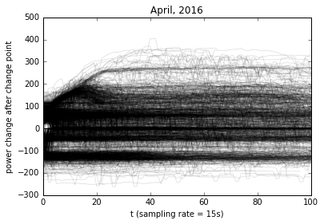

```python
for seg in all_seg_2_4_month:
    plt.plot(seg, 'k-', linewidth=1, alpha=.1)
plt.plot([0,100], [0,0], 'k-', linewidth=1)
plt.xlim([0,100])
plt.xlabel('t (sampling rate = 15s)')
plt.ylabel('power change after change point')
plt.title('April, 2016')
```

**even smaller alpha (transparency)**

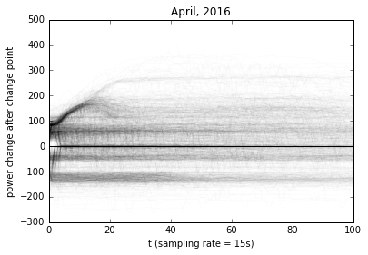

```python
for seg in all_seg_2_4_month:
    plt.plot(seg, 'k-', linewidth=1, alpha=.01)
plt.plot([0,100], [0,0], 'k-', linewidth=1)
plt.xlim([0,100])
plt.xlabel('t (sampling rate = 15s)')
plt.ylabel('power change after change point')
plt.title('April, 2016')
```

**plot by month**

Note the vast difference between different months. Reason? season effect? or reading problems? or initial disaggregate problem?

**important todo**

check out disaggregate in June and July

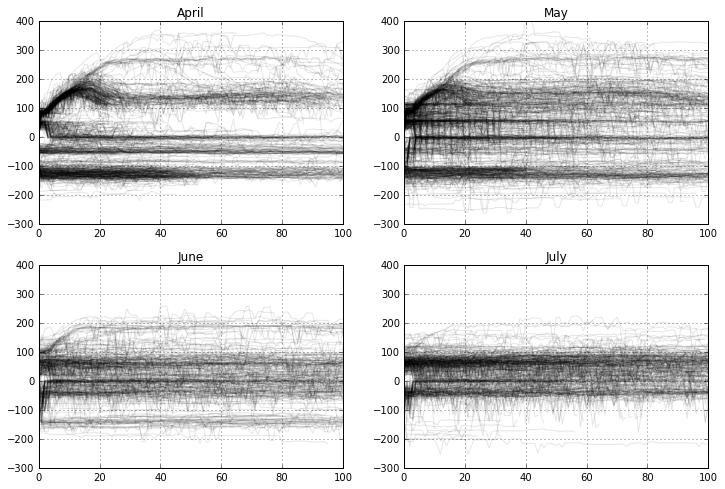

```python
_, ax = plt.subplots(2,2,figsize=[12,8])
ax = ax.flatten()

for i_seg_list, seg_list in enumerate(all_seg_4_month):
    cur_ax = ax[all_seg_time_4_month[i_seg_list][0].month-4]
    for seg in seg_list:
        cur_ax.plot(seg, 'k-', linewidth=1, alpha=.1)

for i in range(4):
    ax[i].set_xlim([0, 100])
    ax[i].set_ylim([-300, 400])
    ax[i].grid()
    if i == 0:
        ax[i].set_title('April')
    elif i == 1:
        ax[i].set_title('May')
    elif i == 2:
        ax[i].set_title('June')
    elif i == 3:
        ax[i].set_title('July')
```